# Effective Smoke Detector Outreach

## 3.3 Final Model

We ensembled the three stories to one final model using the prediction result from each of the stories as independent variable. The average prediction error is 0.399 of a fire. The most powerful story was the neighborhood story, carrying the strong predictors of distance to vacancy and interior violations. The combined strengths of the model ultimately present a story of dense areas, with lower incomes, that are in areas of neglect or needed maintenance.

From the clusters of high number of predicted fire events, it is evident that our model identified the latent risk of fire rather than just perfectly fitting previous fires. Comparing the prediction results of three stories and the final model, we noticed that the final model combined the spatial characteristics of each stories. One can see some of the strong demarcation of census tracts, as well as the nuance of the neighborhood and building stories.

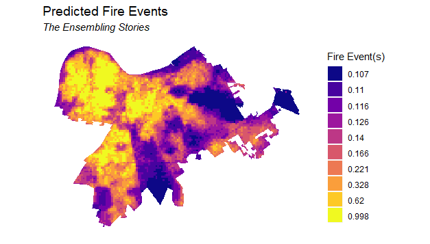

The error is slightly larger in the final model than the most accurate model, the neighborhood story. One can see on the map below that while some of the errors, are very low, at 0.106 fire, the range of errors is larger than the individual stories. This makes sense, due to it being an ensemble of different spatial relationships.

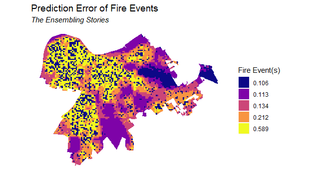

Ultimately the error in accuracy can be considered a tradeoff for generalizability.Validation in the following sections will explore more about how well the final model performs.

## 3.4 Model Validation

We undertook several methods of validation to see how the final model performs. We begin by comparing it to a kernel density map, then test it through cross validation, and then test that cross validation across neighborhoods to determine the generalizability of the model.

### 3.4.1 Kernel Density Comparison

Comparing with a kernel density model is one of the most important forms of validation we can perform. The standard approach to risk mitigation is often to look at a kernel density map to identify risk hot spots. We wanted to be certain that our final model performed better than this traditional approach, to prove that we could offer a better alternative to smoke detector allocation. The results below a map of how the two spatial models compare, with our model showing far more intricacy.

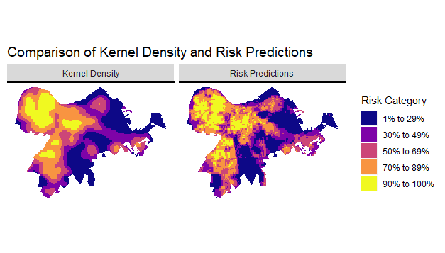

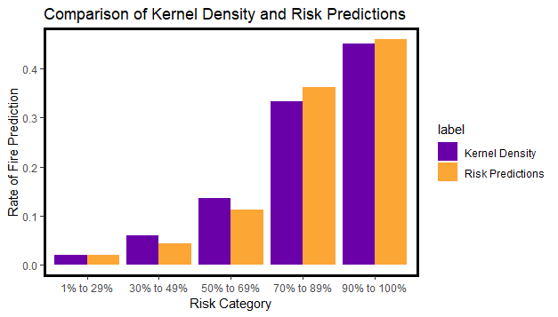

### 3.4.2 Cross Validation

Cross validation helps to verify that the model is generalizable across the dataset, and not only effective on subsets. In order to perform this analysis, we use a test that iterates through 100 random test sets, and averages the error for each of the models. The results of this analysis can be seen in the table below.

The average errors remain relatively comparable to the individual stories. The neighborhood still predicts better than the others, and the ensemble model predicts less well than neighborhood variables, but better than the other stories. These errors show that our final model, is accurate, but has traded some of the accuracy of the neighborhood story in order to be more generalizable.

| Model.Number | Model.Name | Description | Average.MAE |
| --- | --- | --- | --- |
| 1 | regStories.census | Poisson regression; Demographic Variables (6) | 0.434124 |
| 2 | regStories.neighborhood | Poisson regression; Neighborhood Variables (20) | 0.377525 |
| 3 | regStories.building | Poisson regression; Building Variables (20) | 0.403998 |
| 4 | regStories.ensembling | Poisson regression; Using the CV Prediction result from 3 stories | 0.399978 |

### 3.4.3 Spatial Cross Validation

Spatial cross-validation is a robust way to assess the generalizability of our model across space. We have the done this by looking at the distribution of fire prediction errors within different neighborhoods. In this process, fishnet grid cells of one neighborhood will be set aside as a test set, while the rest of the neighborhoods will be used to train the model. By doing so, we can better assess if there is intrinsic bias baked into our model. The spatial distributions of error vary for our three stories, but all of them have fair performance in the downtown area. This observation is likely attributed to the fact that the risk prediction model trades off pinpoint accuracy overfit on past fire events for broader trends of generalizable risk.

The spatial cross validation map of the building story is shows a slight segregation of errors; we can see lower errors in the west side of the city and higher errors in neighborhoods in the east. Therefore, our model predicts better in areas that tend to have more fires as opposed to those that do not. The neighborhood story also has a notable amount of clustering, with lower errors concentrated in the southwest and higher errors in the northeast sides of the city. Again, it is evident that our model has better predictions in areas that have experienced fires, but in this case, we note that it has also performed relatively well regardless of past events, which is a promising indication of generalizability. Spatial cross-validation by the demographic story is less consistent with the other models. While its highest predictive power is primarily in the westernmost neighborhoods, some of the largest errors exist in adjacent neighborhoods. In this sense, it is the most generalizable story because the errors are more randomly distributed throughout space, rather than clustering in certain areas. As such, the demographic story has an important contribution to the overall generalizability of our final ensembled model, which also has slightly less clustering of errors than the neighborhood and building-level stories, and allows our model to predict fire risk at a reasonable scale for the city of Louisville.

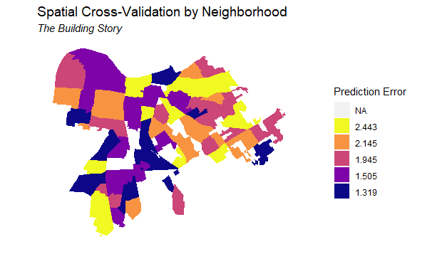

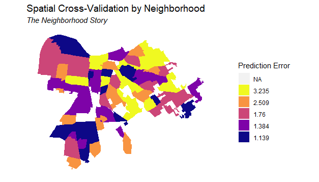

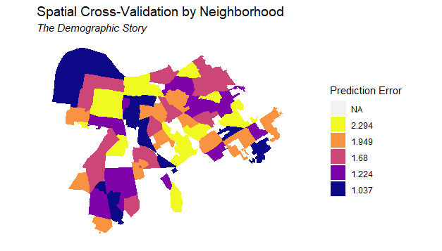

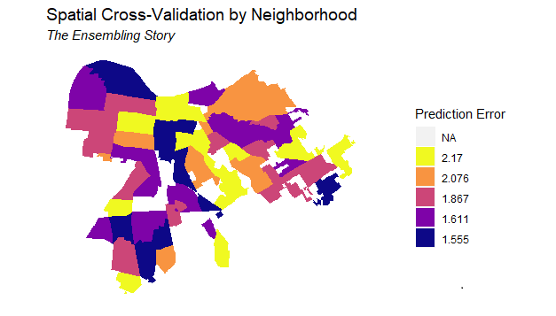

# 4 Looking Forward

Using this final model, we have created risk score categories that are reasonably accurate yet generalizable for the city of Louisville. We then used these categories to build a web app that allows the Louisville Fire Department to identify areas of high risk in which to locate outreach programs. Specifically, the app presents a set of potential venues in at-risk communities such as community centers, churches, and schools, along with a predicted impact assessment within a user-defined radius. These interactions then yield actionable intelligence by enabling the fire department to determine the best locations at which to host outreach programs such as smoke detector distribution events, thereby mitigating risk of fire in Louisville.

# 5 Appendices

## 5.1 Data Dictionary

Our data came from several sources, two of which are publically available:

- [The United States Census](https://factfinder.census.gov/faces/nav/jsf/pages/index.xhtml)
- [Louisville Open Data](https://data.louisvilleky.gov/)
- Louisville Fire Department
- The City of Louisville

One can see the final variables used in the model listed below:

| Variable | Description | Source |
| --- | --- | --- |
| TotalPop | Total population | US Census |
| MedHHInc | Median household income | US Census |
| MedRent | Median rent | US Census |
| percentWhite | Percent white | US Census |
| percentBachelors | Percent with a bachelors degree | US Census |
| percentPoverty | Percent of population in poverty | US Census |
| countInsp | Count of inspections | Louisville Fire Department |
| dens.offsiteowns | Density of offsite owners | City of Louisville |
| nInspHome | Count of home inspections | Louisville Fire Department |
| dist.InspHome3 | Distance to 3 nearest home inspections | Louisville Fire Department |
| nInspOth | Count of other inspections | Louisville Fire Department |
| dist.InspOth5 | Distance to 5 nearest other inspections | Louisville Fire Department |
| dist.InspRe1 | Distance to nearest reinspection | Louisville Fire Department |
| countParcels | Count of parcels (building density) | City of Louisville |
| WALL_TYPE | Property wall type | City of Louisville |
| YEAR_BUILT | Year property was built | City of Louisville |
| nFail | Count of failed inspections | Louisville Fire Department |
| dist.Reinsp3 | Distance to 3 nearest reinspections | Louisville Fire Department |
| nInspGen | Count of general inspections | Louisville Fire Department |
| dens.fireplaces | Density of proeprties with fireplaces | Louisville Open Data |
| dens.built80s | Density of properties built in the 1980s | City of Louisville |
| dens.InspPreplan | Density of preplan inspections | Louisville Fire Department |
| dens.bath12 | Density of properties with less than 3 bathrooms | City of Louisville |
| Prop_Type | Property type | City of Louisville |
| dens.built10s | Density of properties built in the 2010s | City of Louisville |
| distPerm_fdet3 | Distance to 3 nearest fire detector permits | Louisville Open Data |
| dist.elec | Distance to nearest permit - electric | Louisville Open Data |
| dist.fdet | Distance to nearest permit - fire detectors | Louisville Open Data |
| dist.fsup | Distance to nearest permit - fire suppression | Louisville Open Data |
| dist.hvac | Distance to nearest permit - HVAC | Louisville Open Data |
| dist.rhd.1 | Distance to nearest permit - range hood | Louisville Open Data |
| dist.str | Distance to nearest permit - structural inspection | Louisville Open Data |
| dist.vacant | Distance to nearest 311 complaint - vacant property | Louisville Open Data |
| dens.tarcStops | Density of TARC bus stops | Louisville Open Data |
| distOpenB3 | Distance to 3 nearest 311 complaint - open burning | Louisville Open Data |
| distTrash3 | Distance to 3 nearest 311 complaints - trash | Louisville Open Data |
| distIntV3 | Distance to 3 nearest 311 complaints - interior violations | Louisville Open Data |
| dist.Reinsp3 | Distance to 3 nearest reinspections | Louisville Fire Department |
| distPest3 | Distance to 3 nearest 311 complaints - pests | Louisville Open Data |
| dens.warnSirens | Density of warning sirens | Louisville Open Data |
| distExtV3 | Distance to 3 nearest 311 complaints - exterior violations | Louisville Open Data |
| distOverG3 | Distance to 3 nearest 311 complaints - over growth | Louisville Open Data |
| distAbanV3 | Distance to 3 nearest 311 complaints - abandoned vehicles | Louisville Open Data |
| dens.fireStations | Density of fire stations | Louisville Open Data |
| dist.histProperties | Distance to nearest historical property | Louisville Open Data |
| dens.parcTrees | Density of parcel trees | Louisville Open Data |

## 5.2 Data Wrangling

The data for this report came from multiple sources, and required wrangling in order to both acquire the data, and to get it in a usable condition. The following methodology is necessary for processing the data sources and building a final data set. Below, we’ll introduce how to acquire the dependent variable, build a fishnet, process independent variables, run distance and density functions, and finally, to combine them to a completed dataset.

### 5.2.1 Setup

The first step to starting the report is to prime your file. This includes loading in libraries and necessary data sources:

```r
library(dplyr)
library(tidyverse)
library(sf)
library(viridis)
library(corrplot)
library(spdep)
library(leaflet)
library(ggplot2)
library(ggcorrplot)
library(lubridate)
library(FNN)
library(caret)
library(xgboost)
library(spatstat)
library(raster)
library(rasterVis)
library(randomForest)


studyArea <- st_read("Louisville_KY_Fire_Districts.shp") %>% previously LFD
  st_union() %>%
  st_transform(crs=102679)

fires <-
  read.csv("Building_Fires_Cleaned_wLonLat.csv") %>%
  st_as_sf(coords = c("lon", "lat"), crs = 4326) %>%
  st_transform(crs = 102679)
```

### 5.2.2 Creating a Fishnet

The next step was to prepare the unit of analysis by creating a fishnet of the study area. Below, we set our cell size to 500x500 square feet, creating a set of grid cells that is specific enough to show nuanced detail, but not too personalized.

```r
# create a 500x500 foot fishnet
fishnet <-
  st_make_grid(st_union(studyArea), cellsize = 500) %>%
  st_intersection(studyArea, .) %>%
  st_sf() %>%
  mutate(uniqueID = rownames(.))
```

### 5.2.3 Producing a Dependent Variable

The dependent variable must be joined to the fishnet in order for each grid cell to have an affliated fire count. Below, we show how to aggregate each fire to the grid cell level. Each independent variable will also be aggregated, as shown later in this section, eventually giving each grid cell many associated variable values.

```r
# aggregate fire events as count of fires per grid cell
fishnet <-
  fires %>%
  dplyr::select() %>%
  mutate(countFire = 1) %>%
  aggregate(., fishnet, length) %>%
  mutate(countFire = ifelse(is.na(countFire), 0, countFire), uniqueID = rownames(.))
```

### 5.2.4 Producing Independent Variables

Before joining to the fishnet, however, the independent variables must go through a series of filtering and processing. The filtering helps to make the large data sources more manageable, and processing was undertaken in order to make the remaining data more helpful for our analysis.

```r
# select meaningful fields from raw inspection data and rename them
inspections <- inspections %>%
  dplyr::select(Inspection_Completed_Date,
         Inspection_Number,
         Inspection_Type,
         Inspection_Passed_Flag,
         Inspection_Reason,
         Inspection_Reinspection_Flag,
         Inspection_Assigned_To_Shift,
         Inspection_Staff_Hours,
         Inspection_Assigned_To_Station,
         Inspection_Assigned_To_Unit,
         Inspection_Assigned_To_Inspector_Full_Name_List,
         Inspection_Violation_Notice_Sent_Flag,
         Inspection_Reinspection_Parent_Inspection_Number,
         Inspection_Status,
         Agency_ID_Internal,
         Location_ID_Internal,
         Occupants.Occupant_Address_City_Name,
         Occupants.Occupant_Full_Address)
names(inspections) <- c("Completed_Date",
                       "Inspection_Num",
                       "Inspection_Type",
                       "Passed",
                       "Reason",
                       "Reinspection",
                       "Assigned_Shift",
                       "Staff_Hrs",
                       "Assigned_Station",
                       "Assigned_Unit",
                       "Assigned_Names",
                       "Violation_Notice",
                       "Reinspection_Ref",
                       "Status",
                       "Agency_ID",
                       "Location_ID",
                       "City",
                       "Full Address")
```

For other variables, data was aggregated into groups that we found to be very related:

```r
# simplify 311 data categories into broader labels
pests <- complaints %>%
  filter(service_name == "BEDBUGS CODES"|
         service_name == "BEDBUGS HEALTH"|
         service_name == "PESTS"|
         service_name == "VAP STRUC PETS"|
         service_name == "VAP STRUC RATS"|
         service_name == "VAP LOT PESTS"|
         service_name == "VAP LOT RATS"|
         service_name == "HEALTH CONCERNS"|
         service_name == "RAT BAITING")
trash <- complaints %>%
  filter(service_name == "GARBAGE MISSED"|
         service_name == "GARBAGE VIOLATIO"|
         service_name == "ILLEGAL DUMPING"|
         service_name == "JUNK MISSED"|
         service_name == "degt VIOLATION"|
         service_name == "ROADSIDE LITTER"|
         service_name == "TRASH PVT PROP"|
         service_name == "STREET FURNITURE"|
         service_name == "VAP LOT TRASH"|
         service_name == "VAP STRUC TRASH"|
         service_name == "YARD WASTE MISS"|
         service_name == "YARD WASTE VIOL")
```

We also engineered some variables in order to get more explanatory value out of them. In this example, we thought there would be variation between each decade in the year built. We engineered it in order to see if there were patterns in terms of when structures were constructed:

```r
# feature engineer data into new variables
PVA <- PVA %>%
  mutate(BUILTPRE30S = ifelse(PVA$YEAR_BUILT < 1930 & PVA$YEAR_BUILT > 0, 1, 0),
BUILT30s = ifelse(PVA$YEAR_BUILT < 1940 & PVA$YEAR_BUILT >= 1930, 1, 0),
BUILT40s = ifelse(PVA$YEAR_BUILT < 1950 & PVA$YEAR_BUILT >= 1940, 1, 0),
BUILT50s = ifelse(PVA$YEAR_BUILT < 1960 & PVA$YEAR_BUILT >= 1950, 1, 0),
BUILT60s = ifelse(PVA$YEAR_BUILT < 1970 & PVA$YEAR_BUILT >= 1960, 1, 0),
BUILT70s = ifelse(PVA$YEAR_BUILT < 1980 & PVA$YEAR_BUILT >= 1970, 1, 0),
BUILT80s = ifelse(PVA$YEAR_BUILT < 1990 & PVA$YEAR_BUILT >= 1980, 1, 0),
BUILT90s = ifelse(PVA$YEAR_BUILT < 2000 & PVA$YEAR_BUILT >= 1990, 1, 0),
BUILT00s = ifelse(PVA$YEAR_BUILT < 2010 & PVA$YEAR_BUILT >= 2000, 1, 0),
BUILT10s = ifelse(PVA$YEAR_BUILT < 2020 & PVA$YEAR_BUILT >= 2010, 1, 0))
```

Other variables came from the Census API, in which we gathered the variables needed for our analysis. The code below gathers the variables, renames them so that they are recognizable, and then calculates percentages:

```r
#gather census variables
tract10 <-
  get_acs(geography = "tract", variables = c("B25026_001E","B02001_002E","B15001_050E",
                                             "B15001_009E","B19013_001E","B25058_001E",
                                             "B06012_002E"),
          endyear = 2010, state='KY', county='Jefferson', geometry=T) %>%
  select(variable,estimate) %>%
  as.data.frame() %>%
  spread(variable,estimate) %>%
  rename(TotalPop=B25026_001,
         NumberWhites=B02001_002,
         TotalFemaleBachelors=B15001_050,
         TotalMaleBachelors=B15001_009,
         MedHHInc=B19013_001,
         MedRent=B25058_001,
         TotalPoverty=B06012_002) %>%
  mutate(percentWhite = ifelse(TotalPop > 0, NumberWhites / TotalPop,0),
         percentBachelors = ifelse(TotalPop > 0, ((TotalFemaleBachelors + TotalMaleBachelors) / TotalPop),0),
         percentPoverty = ifelse(TotalPop > 0, TotalPoverty / TotalPop, 0),
         year = "2010") %>%
  select(-NumberWhites,-TotalFemaleBachelors,-TotalMaleBachelors,-TotalPoverty) %>%
  st_sf() %>%
  st_transform(102679)
```

### 5.2.5 Kernel Density

Kernel density is a way to show hot spots of different variables, giving us a different way of explaining each variables predictive power. Below, we show a few examples for how to transform variables into this type of spatial feature:

```r
#create kernel density function

dataXY_function <- function(data) {
  dataXY <- data %>%
    st_coordinates() %>%
    as.data.frame() %>%
    dplyr :: select(X,Y) %>%
    as.matrix()
  return(dataXY)
}

kernel_function <- function(DATASET, WINDOW, MASK, SIGMA) {
  data.xy <- dataXY_function(DATASET)
  data.ppp <- as.ppp(data.xy, WINDOW)
  data.dens <- spatstat::density.ppp(data.ppp, sigma = SIGMA)
  density <- raster::extract(raster(data.dens), MASK, fun = mean) %>%
    as.data.frame()
  names(density) <- c("dens")
  return(density)
}
```

Below, one determines the bounding box of the study area, in order to limit the processing area of the raster:

```r
#determine bounding box for study area

boundingBox <- st_bbox(studyArea)
xMinMax <- c(boundingBox[1,], boundingBox[3,])
yMinMax <- c(boundingBox[2,], boundingBox[4,])

studyWindow <- owin(xMinMax, yMinMax)
mask <- fishnet %>% as('Spatial') %>% as('SpatialPolygons')
```

Then one can process each variable. Below, inspection data is turned into kernel densities using the mask created above, and with a search distance of 1500 feet:

```r
homeInsp <- kernel_function(homeInsp, studyWindow, mask, 1500)
newConstInsp <- kernel_function(newConstInsp, studyWindow, mask, 1500)
genInsp <- kernel_function(genInsp, studyWindow, mask, 1500)
otherInsp <- kernel_function(otherInsp, studyWindow, mask, 1500)
reInsp <- kernel_function(reInsp, studyWindow, mask, 1500)
planRevInsp <- kernel_function(planRevInsp, studyWindow, mask, 1500)
prePlanInsp <- kernel_function(prePlanInsp, studyWindow, mask, 1500)
```

### 5.2.6 Distance and Nearest Neighbors

Another important method of processing independent variables is finding their relative distances. Two different kinds of distances are measured: distance to one nearest object, and dearest to n nearest neighbors. They use the same code, but the n value changes, as shown below. These variables are then joined back to the fishnet with the others.

```r
#distance function

nn_function <- function(measureFrom, measureTo, k) {
  nn <- get.knnx(measureTo, measureFrom, k)$nn.dist
  output <-
    as.data.frame(nn) %>%
    rownames_to_column(var = "thisPoint") %>%
    gather(points, point_distance, V1:ncol(.)) %>%
    arrange(as.numeric(thisPoint)) %>%
    group_by(thisPoint) %>%
    summarize(pointDistance = mean(point_distance)) %>%
    arrange(as.numeric(thisPoint)) %>%
    dplyr::select(-thisPoint) %>%
    as.data.frame()
  names(output) <- c("dist")
  return(output)
}
```

Once the function is created, each variable can be processed as desired. In this example, first the fishnet was converted to a datapoint, creating a center point. From this center point, distances could be processedto each individual variable. Below, different kinds of building permits were transformed to show both the distance to their nearest neighbor, as well as the distance to their nearest three neighbors.

```r
fishxy <- dataXY_function(fishnet)
distPermBldg3 <- nn_function(fishxy, dataXY_function(perm.bldg), 3)
distPermElec3 <- nn_function(fishxy, dataXY_function(perm.elec), 3)
distPermHvac3 <- nn_function(fishxy, dataXY_function(perm.hvac), 3)
distPermBldg3 <- nn_function(fishxy, dataXY_function(perm.bldg), 1)
distPermElec3 <- nn_function(fishxy, dataXY_function(perm.elec), 1)
distPermHvac3 <- nn_function(fishxy, dataXY_function(perm.hvac), 1)
```

### 5.2.7 Finalizing the Dataset

Finally, all of the variables are joined together to create a master dataset. The code below shows how to join together the newly created variables to the final fishnet, including some density and distance examples:

```r
fishnet <- fishnet %>%
  mutate(dens.InspHome = homeInsp$dens,
    dens.InspNewC = newConstInsp$dens,
    dens.InspGen = genInsp$dens,
    dens.InspOth = otherInsp$dens,
    dens.InspRe = reInsp$dens,
    dens.InspPlan = planRevInsp$dens,
    dens.InspPreplan = prePlanInsp$dens,
distPerm_bldg3 = distPermBldg3$dist,
distPerm_elec3 = distPermElec3$dist
distPerm_hvac3 = distPermHvac3$dist)
```

## 5.3 Data Visualization

Visualisation is important for communicating your material clearly. We chose to begin by creative a cohesive visual theme, to minimize distracts and make understanding the data simpler.

To begin, we picked a color theme using the Viridis package:

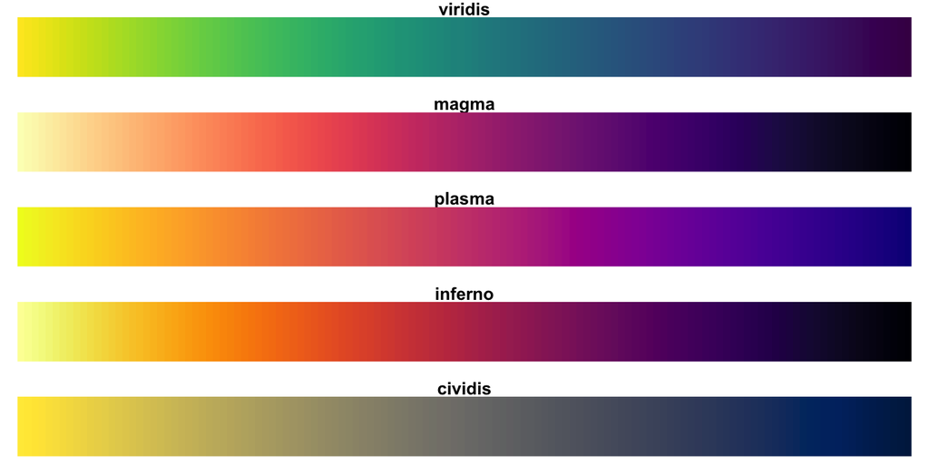

And settled on the theme “plasma”.

Another step was to choose map and plot themes, making for a more cohensive look:

```r
#map theme
mapTheme <- function(base_size = 12) {
  theme(
    text = element_text(color = "black"),
    plot.title = element_text(size = 16, colour = "black", face = "bold"),
    plot.subtitle=element_text(size = 12, face="italic"),
    plot.caption=element_text(hjust=0),
    axis.ticks = element_blank(),
    panel.background = element_rect(fill = "white"),
    axis.title = element_blank(),
    axis.text = element_blank(),
    axis.title.x = element_blank(),
    axis.title.y = element_blank(),
    panel.grid.major = element_line(colour="white"),
    panel.grid.minor = element_line(colour = "white"),
    panel.border = element_blank()
  )
}

#plot theme
plotTheme <- function(base_size = 12) {
  theme(panel.grid.major = element_blank(), panel.grid.minor = element_blank(),
        panel.background = element_blank(), axis.line = element_line(colour = "black"),
        panel.border = element_rect(colour = "black", fill=NA, size=2))
}
```

While most of the maps used raster plots or the fishnet in their visualization, the count data was sometimes set on a basemap. The following code identifies how to make one, starting with loading in a few basic shapefiles usually found in open data. We used the fire districts as our boundary:

```r
# base map

LFD <- st_read("Louisville_KY_Fire_Districts.shp")

# transform the map to the correct projection, and then run "union" to dissolve borders

st_transform(LFD, crs = 102679)
LFD <- st_transform(st_union(LFD), crs=102679)

# water

river <- st_read("waterClip.shp")

# parks

parks <- st_read("parkClip.shp")

# highways

roads <- st_read("hwyClip.shp")

#map it

baseMap <- ggplot() +
  geom_sf(data = LFD, aes(), fill = "grey85", color = NA, size = 1) +
  geom_sf(data = roads, aes(), fill = NA, color = "white") +
  geom_sf(data = river, aes(), fill = "slategray2", color = NA) +
  geom_sf(data = parks, aes(), fill = "palegreen", color = NA) +
  mapTheme()
```